# Notebook 08: Integrate And Interpret Findings

Author

Shirshak Aryal

Published

July 3, 2026

This notebook integrates:

- **Notebook 06 (Pathway Enrichment) findings**
- **Notebook 07 (Deconvolution) findings**
- **Patient clinical metadata**

to construct a **unified biological portrait of Proneural (PN) and Mesenchymal (ME) GBM subtypes**, and to test whether the biological differences between these subtypes carry **clinical consequences for patient survival**.

The central analytical goal is a **Cox proportional hazards model:**

- A **multivariate** survival model (a **statistical model**, not a machine learning model) that **simultaneously** **tests** **whether** **pathway activity, cellular composition, and subtype independently predict how long patients survive**, controlling for all other variables at once.
- Unlike simpler approaches that test one variable at a time, the Cox model asks: “of all the biological differences between ME and PN tumors, **which ones actually matter for survival, independently of each other?**”

To **ensure the Cox model receives the** **highest-quality, non-redundant inputs,** the following **preparatory steps** are performed:

- **Pathway synthesis**: **ORA and GSEA results (Notebook 06)** are synthesised to **identify the dominant biological themes distinguishing ME from PN tumors,** establishing what the transcriptional differences between subtypes actually mean biologically.
- **Per-sample pathway activity scoring (GSVA)**: Subtype-level pathway findings (i.e. the **ORA and GSEA results**) are **translated into** **per-sample continuous scores**, making **pathway activity** a variable that can be **measured for each individual tumor sample** rather than just compared between subtypes.
- **Deconvolution-pathway correlation**: **Cell type abundance scores (Notebook 07)** are **correlated** against **GSVA pathway scores across all samples**, identifying **which cell types drive each biological theme** and **flagging redundant variables** before modelling.
- **Input selection**: Based on the correlation analysis, the final Cox model inputs are:
  - **Subtype (ME vs PN)**: The primary biological grouping variable
  - **Pathways: One representative GSVA score per biological theme**:
    - One **immune pathway** score
    - One **neural pathway** score
    - One **proliferation pathway** score

      selected as the **highest-confidence representative of each theme**
  - **Key cell type abundance scores**: Specifically **those identified by the correlation analysis** as **independently driving pathway activity** rather than being redundant with each other or with the GSVA scores
  - **Age of patient at diagnosis**: The **single most established clinical confounder in GBM survival**, included to **ensure subtype effects are not confounded by patient age.**

  The **outcome variable is overall survival**, defined as **time from diagnosis to death** **(or last follow-up if censored)**

**Before** the Cox model, a **Kaplan-Meier (KM) survival curve** is plotted.

- **KM curve** is a **step-function curve** (i.e. a curve that **only moves in discrete downward steps** rather than smoothly) that **drops each time a patient dies** and staying **flat between deaths**. It shows what **fraction of patients in each subtype remain alive at each timepoint.**
- **One curve** for **ME** patients, **one** for **PN** patients
- To **visually confirm that a survival difference between subtypes exists in this dataset** before attempting to explain it. This serves as a **sanity check**: **if** ME and PN show **no survival difference** at all in the KM plot, the **Cox model has nothing to explain**.

**After** fitting the Cox model, a **Schoenfeld residuals plot** is produced:

- A **diagnostic check of the model’s core assumption** that the **effect of each predictor (i.e. input variable) on survival risk remains constant over time** (the “proportional hazards” assumption).
- **If residuals show no systematic trend over time, the assumption holds**. **If** any predictor shows a **trend**, it is corrected via stratification or time-interaction terms before results are interpreted.

## 1. Import Libraries

```r
library(tidyverse)    # data manipulation and visualisation
library(patchwork)    # combine multiple ggplot2 plots into one canvas
library(survival)     # survival analysis (Kaplan-Meier, Cox proportional hazards)
library(survminer)    # publication-ready survival curve visualisation
library(GSVA)         # single-sample gene set enrichment scoring (per-sample pathway activity)
library(org.Hs.eg.db) # human gene annotation database (Ensembl symbol mapping)
library(broom)        # tidying Cox model outputs into clean, readable dataframes

cat("\nLibraries loaded successfully\n")
```

```
Libraries loaded successfully
```

```r
cat("tidyverse version:    ", as.character(packageVersion("tidyverse")), "\n")
```

```
tidyverse version:     2.0.0
```

```r
cat("patchwork version:    ", as.character(packageVersion("patchwork")), "\n")
```

```
patchwork version:     1.3.2
```

```r
cat("survival version:     ", as.character(packageVersion("survival")), "\n")
```

```
survival version:      3.8.6
```

```r
cat("survminer version:    ", as.character(packageVersion("survminer")), "\n")
```

```
survminer version:     0.5.2
```

```r
cat("GSVA version:         ", as.character(packageVersion("GSVA")), "\n")
```

```
GSVA version:          2.4.4
```

```r
cat("org.Hs.eg.db version: ", as.character(packageVersion("org.Hs.eg.db")), "\n")
```

```
org.Hs.eg.db version:  3.22.0
```

```r
cat("broom version:         ", as.character(packageVersion("broom")), "\n")
```

```
broom version:          1.0.13
```

## 2. Load Data

### 2.1. Load Filtered Counts Matrix

```r
filtered_counts_matrix <- readRDS("../01_data/02_processed/04_filtered_counts_matrix.rds")
cat("Filtered counts matrix loaded:", nrow(filtered_counts_matrix), "genes x", ncol(filtered_counts_matrix), "samples\n")
```

```
Filtered counts matrix loaded: 16164 genes x 180 samples
```

### 2.2. Load Filtered Tumor Subtype Information

```r
tumor_subtype_info <- readRDS("../01_data/02_processed/05_filtered_tumor_subtype_info.rds")
cat("Filtered tumor subtype info loaded:", nrow(tumor_subtype_info), "samples\n")
```

```
Filtered tumor subtype info loaded: 180 samples
```

```r
cat("\nColumn names:\n")
```

```
Column names:
```

```r
print(colnames(tumor_subtype_info))
```

```
  [1] "barcode"
  [2] "patient"
  [3] "sample"
  [4] "shortLetterCode"
  [5] "definition"
  [6] "sample_submitter_id"
  [7] "intermediate_dimension"
  [8] "tumor_descriptor"
  [9] "sample_id"
 [10] "pathology_report_uuid"
 [11] "submitter_id"
 [12] "shortest_dimension"
 [13] "sample_type"
 [14] "specimen_type"
 [15] "longest_dimension"
```

[output cut: 92 more lines]

### 2.3. Load Clinical Metadata

```r
clinical_metadata <- readRDS("../01_data/01_raw/02_clinical/01_clinical_metadata.rds")
cat("Clinical metadata loaded:", nrow(clinical_metadata), "patients\n")
```

```
Clinical metadata loaded: 617 patients
```

```r
cat("\nColumn names:\n")
```

```
Column names:
```

```r
print(colnames(clinical_metadata))
```

```
  [1] "project"
  [2] "submitter_id"
  [3] "morphology"
  [4] "days_to_diagnosis"
  [5] "created_datetime"
  [6] "tissue_or_organ_of_origin"
  [7] "age_at_diagnosis"
  [8] "primary_diagnosis"
  [9] "classification_of_tumor"
 [10] "tumor_of_origin"
 [11] "updated_datetime"
 [12] "diagnosis_id"
 [13] "site_of_resection_or_biopsy"
 [14] "state"
 [15] "prior_treatment"
```

[output cut: 142 more lines]

**NOTE:** The **GDC clinical metadata was inspected for additional covariates beyond those already available in the paper-curated `tumor_subtype_info` columns.** **All potentially useful clinical variables** (treatment, recurrence, disease status) were found to be **>83% missing**, which is a **known limitation of TCGA’s retrospectively collected clinical records**. The **clinical metadata is therefore not used as a source of additional covariates in this analysis.** **Survival analysis relies exclusively on the paper-curated columns from Verhaak et al. (2010),** which provide **complete survival and demographic data for** **all 180 samples**.

### 2.4. Load Pathway Enrichment Results

```r
ora_consensus_up_go     <- read_csv("../04_results/06_pathway_enrichment/01_ora/01_ora_consensus_upregulated_gobp.csv")
ora_consensus_up_kegg   <- read_csv("../04_results/06_pathway_enrichment/01_ora/02_ora_consensus_upregulated_kegg.csv")
ora_consensus_down_go   <- read_csv("../04_results/06_pathway_enrichment/01_ora/03_ora_consensus_downregulated_gobp.csv")
ora_consensus_down_kegg <- read_csv("../04_results/06_pathway_enrichment/01_ora/04_ora_consensus_downregulated_kegg.csv")

gsea_consensus_up_go     <- read_csv("../04_results/06_pathway_enrichment/02_gsea/01_gsea_consensus_upregulated_gobp.csv")
gsea_consensus_up_kegg   <- read_csv("../04_results/06_pathway_enrichment/02_gsea/02_gsea_consensus_upregulated_kegg.csv")
gsea_consensus_down_go   <- read_csv("../04_results/06_pathway_enrichment/02_gsea/03_gsea_consensus_downregulated_gobp.csv")
gsea_consensus_down_kegg <- read_csv("../04_results/06_pathway_enrichment/02_gsea/04_gsea_consensus_downregulated_kegg.csv")




cat("ORA upregulated GO:BP terms:    ", nrow(ora_consensus_up_go), "\n")
```

```
ORA upregulated GO:BP terms:     390
```

```r
cat("ORA upregulated KEGG terms:     ", nrow(ora_consensus_up_kegg), "\n")
```

```
ORA upregulated KEGG terms:      74
```

```r
cat("ORA downregulated GO:BP terms:  ", nrow(ora_consensus_down_go), "\n")
```

```
ORA downregulated GO:BP terms:   164
```

```r
cat("ORA downregulated KEGG terms:   ", nrow(ora_consensus_down_kegg), "\n\n")
```

```
ORA downregulated KEGG terms:    30
```

```r
cat("GSEA upregulated GO:BP terms:   ", nrow(gsea_consensus_up_go), "\n")
```

```
GSEA upregulated GO:BP terms:    360
```

```r
cat("GSEA upregulated KEGG terms:    ", nrow(gsea_consensus_up_kegg), "\n")
```

```
GSEA upregulated KEGG terms:     97
```

```r
cat("GSEA downregulated GO:BP terms: ", nrow(gsea_consensus_down_go), "\n")
```

```
GSEA downregulated GO:BP terms:  125
```

```r
cat("GSEA downregulated KEGG terms:  ", nrow(gsea_consensus_down_kegg), "\n")
```

```
GSEA downregulated KEGG terms:   22
```

### 2.5. Load Deconvolution Results

```r
deconv_primary_df      <- readRDS("../04_results/07_deconvolution/01_primary_deconvolution_results.rds")
deconv_confirmatory_df <- readRDS("../04_results/07_deconvolution/02_confirmatory_deconvolution_results.rds")

cat("Primary deconvolution results:     ", dim(deconv_primary_df), "\n")
```

```
Primary deconvolution results:      180 21
```

```r
cat("Confirmatory deconvolution results:", dim(deconv_confirmatory_df), "\n")
```

```
Confirmatory deconvolution results: 180 21
```

```r
cat("\nPrimary deconvolution cell types:\n")
```

```
Primary deconvolution cell types:
```

```r
print(colnames(deconv_primary_df))
```

```
 [1] "sample_id"       "AC"              "MES"             "NPC"
 [5] "OPC"             "Astrocyte"       "Oligodendrocyte" "Neuron"
 [9] "Radial glial"    "Monocytes"       "TAM"             "Microglia"
[13] "DC"              "Mast cells"      "T cells"         "NK cells"
[17] "B cells"         "Plasma B"        "Mural cell"      "Endothelial"
[21] "subtype"
```

```r
cat("\n\nConfirmatory deconvolution cell types:\n")
```

```
Confirmatory deconvolution cell types:
```

```r
print(colnames(deconv_confirmatory_df))
```

```
 [1] "sample_id"       "AC"              "MES"             "NPC"
 [5] "OPC"             "Astrocyte"       "Oligodendrocyte" "Neuron"
 [9] "Radial glial"    "Monocytes"       "TAM"             "Microglia"
[13] "DC"              "Mast cells"      "T cells"         "NK cells"
[17] "B cells"         "Plasma B"        "Mural cell"      "Endothelial"
[21] "subtype"
```

## 3. Refine Inputs For Cox Proportional Hazards Model

### 3.1. Identify Dominant Biological Themes Per Subtype From Pathway Enrichment Results

#### 3.1.1. Tabulate ORA Consensus Pathways

```r
# GO:BP
# filter results to significant terms only
ora_consensus_up_go_sig   <- ora_consensus_up_go   %>% filter(p.adjust < 0.05) %>% arrange(p.adjust)
ora_consensus_down_go_sig <- ora_consensus_down_go %>% filter(p.adjust < 0.05) %>% arrange(p.adjust)

cat("Significant ORA GO:BP terms: Upregulated in ME:  ", nrow(ora_consensus_up_go_sig), "\n")
```

```
Significant ORA GO:BP terms: Upregulated in ME:   390
```

```r
cat("Significant ORA GO:BP terms: Downregulated in ME:", nrow(ora_consensus_down_go_sig), "\n\n")
```

```
Significant ORA GO:BP terms: Downregulated in ME: 164
```

```r
cat("Top 10 ORA GO:BP terms upregulated in ME:\n")
```

```
Top 10 ORA GO:BP terms upregulated in ME:
```

```r
ora_consensus_up_go_sig %>%
  dplyr::select(Description, p.adjust, Count) %>%
  mutate(p.adjust = formatC(p.adjust, format = "e", digits = 2)) %>%
  head(10) %>%
  knitr::kable()
```

| Description | p.adjust | Count |
| --- | --- | --- |
| leukocyte migration | 2.62e-42 | 128 |
| cell chemotaxis | 1.44e-33 | 105 |
| leukocyte proliferation | 2.12e-28 | 108 |
| regulation of leukocyte migration | 1.62e-27 | 80 |
| myeloid leukocyte activation | 3.15e-27 | 86 |
| extracellular matrix organization | 3.45e-26 | 94 |
| lymphocyte proliferation | 2.87e-25 | 96 |
| regulation of leukocyte proliferation | 7.18e-25 | 92 |
| T cell differentiation | 1.24e-23 | 89 |
| positive regulation of inflammatory response | 2.27e-23 | 66 |

```r
cat("\nTop 10 ORA GO:BP terms downregulated in ME:\n")
```

```
Top 10 ORA GO:BP terms downregulated in ME:
```

```r
ora_consensus_down_go_sig %>%
  dplyr::select(Description, p.adjust, Count) %>%
  mutate(p.adjust = formatC(p.adjust, format = "e", digits = 2)) %>%
  head(10) %>%
  knitr::kable()
```

| Description | p.adjust | Count |
| --- | --- | --- |
| central nervous system neuron differentiation | 1.24e-15 | 53 |
| regulation of postsynaptic membrane potential | 1.24e-15 | 42 |
| synapse assembly | 1.24e-15 | 58 |
| regulation of synapse structure or activity | 1.89e-15 | 63 |
| axonogenesis | 2.36e-15 | 75 |
| cell-cell adhesion via plasma-membrane adhesion molecules | 4.60e-15 | 58 |
| regulation of synapse organization | 2.09e-14 | 60 |
| nucleosome assembly | 5.03e-14 | 36 |
| nucleosome organization | 8.85e-13 | 37 |
| protein localization to CENP-A containing chromatin | 1.72e-11 | 13 |

```r
# KEGG
# filter results to significant terms only
ora_consensus_up_kegg_sig   <- ora_consensus_up_kegg   %>% filter(p.adjust < 0.05) %>% arrange(p.adjust)
ora_consensus_down_kegg_sig <- ora_consensus_down_kegg %>% filter(p.adjust < 0.05) %>% arrange(p.adjust)

cat("\nSignificant ORA KEGG terms — Upregulated in ME:  ", nrow(ora_consensus_up_kegg_sig), "\n")
```

```
Significant ORA KEGG terms — Upregulated in ME:   74
```

```r
cat("Significant ORA KEGG terms — Downregulated in ME:", nrow(ora_consensus_down_kegg_sig), "\n\n")
```

```
Significant ORA KEGG terms — Downregulated in ME: 30
```

```r
cat("Top 10 ORA KEGG terms upregulated in ME:\n")
```

```
Top 10 ORA KEGG terms upregulated in ME:
```

```r
ora_consensus_up_kegg_sig %>%
  dplyr::select(Description, p.adjust, Count) %>%
  mutate(p.adjust = formatC(p.adjust, format = "e", digits = 2)) %>%
  head(10) %>%
  knitr::kable()
```

| Description | p.adjust | Count |
| --- | --- | --- |
| Cytokine-cytokine receptor interaction | 1.56e-32 | 102 |
| Viral protein interaction with cytokine and cytokine receptor | 2.96e-25 | 51 |
| Rheumatoid arthritis | 9.31e-18 | 42 |
| Hematopoietic cell lineage | 9.40e-18 | 43 |
| Osteoclast differentiation | 1.30e-15 | 49 |
| Complement and coagulation cascades | 6.61e-14 | 36 |
| Staphylococcus aureus infection | 4.62e-13 | 37 |
| TNF signaling pathway | 2.08e-12 | 40 |
| Leishmaniasis | 7.66e-12 | 31 |
| Phagocytosis | 1.15e-11 | 62 |

```r
cat("\nTop 10 ORA KEGG terms downregulated in ME:\n")
```

```
Top 10 ORA KEGG terms downregulated in ME:
```

```r
ora_consensus_down_kegg_sig %>%
  dplyr::select(Description, p.adjust, Count) %>%
  mutate(p.adjust = formatC(p.adjust, format = "e", digits = 2)) %>%
  head(10) %>%
  knitr::kable()
```

| Description | p.adjust | Count |
| --- | --- | --- |
| Alcoholism | 4.43e-29 | 61 |
| Systemic lupus erythematosus | 6.64e-23 | 47 |
| Neutrophil extracellular trap formation | 2.18e-18 | 49 |
| Neuroactive ligand signaling | 9.14e-16 | 46 |
| Neuroactive ligand-receptor interaction | 2.28e-11 | 57 |
| Glutamatergic synapse | 1.78e-08 | 26 |
| Nicotine addiction | 5.94e-07 | 14 |
| Synaptic vesicle cycle | 4.98e-06 | 18 |
| cAMP signaling pathway | 4.98e-06 | 33 |
| Dopaminergic synapse | 6.84e-05 | 22 |

#### 3.1.3. Tabulate GSEA Consensus Pathways

```r
# GO:BP
# filter results to significant terms only
gsea_consensus_up_go_sig   <- gsea_consensus_up_go   %>% filter(p.adjust < 0.05) %>% arrange(p.adjust)
gsea_consensus_down_go_sig <- gsea_consensus_down_go %>% filter(p.adjust < 0.05) %>% arrange(p.adjust)

cat("Significant GSEA GO:BP terms — Upregulated in ME:  ", nrow(gsea_consensus_up_go_sig), "\n")
```

```
Significant GSEA GO:BP terms — Upregulated in ME:   360
```

```r
cat("Significant GSEA GO:BP terms — Downregulated in ME:", nrow(gsea_consensus_down_go_sig), "\n\n")
```

```
Significant GSEA GO:BP terms — Downregulated in ME: 125
```

```r
cat("Top 10 GSEA GO:BP terms upregulated in ME:\n")
```

```
Top 10 GSEA GO:BP terms upregulated in ME:
```

```r
gsea_consensus_up_go_sig %>%
  dplyr::select(Description, NES, p.adjust) %>%
  mutate(
    NES      = round(NES, 3),
    p.adjust = formatC(p.adjust, format = "e", digits = 2)
  ) %>%
  head(10) %>%
  knitr::kable()
```

| Description | NES | p.adjust |
| --- | --- | --- |
| cytokine-mediated signaling pathway | 2.960 | 1.02e-45 |
| adaptive immune response | 3.024 | 5.19e-44 |
| positive regulation of cytokine production | 2.873 | 8.37e-41 |
| leukocyte mediated immunity | 3.010 | 2.57e-38 |
| leukocyte migration | 3.006 | 2.57e-38 |
| regulation of immune effector process | 3.001 | 4.52e-38 |
| regulation of inflammatory response | 2.970 | 5.08e-37 |
| leukocyte proliferation | 3.025 | 1.93e-36 |
| leukocyte cell-cell adhesion | 2.888 | 3.28e-36 |
| cell chemotaxis | 3.086 | 7.90e-35 |

```r
cat("\nTop 10 GSEA GO:BP terms downregulated in ME:\n")
```

```
Top 10 GSEA GO:BP terms downregulated in ME:
```

```r
gsea_consensus_down_go_sig %>%
  dplyr::select(Description, NES, p.adjust) %>%
  mutate(
    NES      = round(NES, 3),
    p.adjust = formatC(p.adjust, format = "e", digits = 2)
  ) %>%
  head(10) %>%
  knitr::kable()
```

| Description | NES | p.adjust |
| --- | --- | --- |
| chromosome segregation | -2.664 | 1.63e-26 |
| nuclear chromosome segregation | -2.649 | 1.55e-21 |
| sister chromatid segregation | -2.735 | 1.76e-19 |
| nuclear division | -2.346 | 2.45e-18 |
| mRNA processing | -2.283 | 4.58e-18 |
| protein-DNA complex organization | -2.608 | 2.72e-17 |
| regulation of chromosome organization | -2.581 | 9.32e-17 |
| protein-DNA complex assembly | -2.637 | 1.70e-16 |
| regulation of chromosome segregation | -2.830 | 2.82e-16 |
| double-strand break repair | -2.337 | 1.61e-15 |

```r
# KEGG
# filter results to significant terms only
gsea_consensus_up_kegg_sig   <- gsea_consensus_up_kegg   %>% filter(p.adjust < 0.05) %>% arrange(p.adjust)
gsea_consensus_down_kegg_sig <- gsea_consensus_down_kegg %>% filter(p.adjust < 0.05) %>% arrange(p.adjust)

cat("\nSignificant GSEA KEGG terms — Upregulated in ME:  ", nrow(gsea_consensus_up_kegg_sig), "\n")
```

```
Significant GSEA KEGG terms — Upregulated in ME:   97
```

```r
cat("Significant GSEA KEGG terms — Downregulated in ME:", nrow(gsea_consensus_down_kegg_sig), "\n\n")
```

```
Significant GSEA KEGG terms — Downregulated in ME: 22
```

```r
cat("Top 10 GSEA KEGG terms upregulated in ME:\n")
```

```
Top 10 GSEA KEGG terms upregulated in ME:
```

```r
gsea_consensus_up_kegg_sig %>%
  dplyr::select(Description, NES, p.adjust) %>%
  mutate(
    NES      = round(NES, 3),
    p.adjust = formatC(p.adjust, format = "e", digits = 2)
  ) %>%
  head(10) %>%
  knitr::kable()
```

| Description | NES | p.adjust |
| --- | --- | --- |
| Cytokine-cytokine receptor interaction | 2.934 | 2.79e-26 |
| Viral protein interaction with cytokine and cytokine receptor | 3.070 | 1.10e-18 |
| NOD-like receptor signaling pathway | 2.746 | 2.34e-17 |
| Staphylococcus aureus infection | 3.062 | 4.09e-17 |
| Osteoclast differentiation | 2.800 | 4.09e-17 |
| Hematopoietic cell lineage | 2.947 | 1.64e-16 |
| Complement and coagulation cascades | 2.984 | 1.98e-16 |
| NF-kappa B signaling pathway | 2.796 | 1.54e-15 |
| Herpes simplex virus 1 infection | 2.642 | 3.30e-15 |
| Tuberculosis | 2.630 | 4.72e-15 |

```r
cat("\nTop 10 GSEA KEGG terms downregulated in ME:\n")
```

```
Top 10 GSEA KEGG terms downregulated in ME:
```

```r
gsea_consensus_down_kegg_sig %>%
  dplyr::select(Description, NES, p.adjust) %>%
  mutate(
    NES      = round(NES, 3),
    p.adjust = formatC(p.adjust, format = "e", digits = 2)
  ) %>%
  head(10) %>%
  knitr::kable()
```

| Description | NES | p.adjust |
| --- | --- | --- |
| Cell cycle | -2.412 | 1.06e-10 |
| Spliceosome | -2.164 | 5.45e-08 |
| Nucleocytoplasmic transport | -2.164 | 9.03e-07 |
| ATP-dependent chromatin remodeling | -2.135 | 9.32e-07 |
| Fanconi anemia pathway | -2.292 | 5.50e-06 |
| Alcoholism | -1.966 | 6.32e-06 |
| Glutamatergic synapse | -1.992 | 2.08e-05 |
| Nicotine addiction | -2.191 | 6.25e-05 |
| Neuroactive ligand signaling | -1.767 | 2.09e-04 |
| Polycomb repressive complex | -1.929 | 2.12e-04 |

#### 3.1.4. Identify Dominant Biological Themes

```r
# build one row per direction, summarising ORA and GSEA findings
pathway_analysis_results_integrated_summary <- data.frame(
  Direction = c("Up in ME", "Down in ME (Up in PN)"),

  `Top 5 ORA Pathways` = c(
    paste(ora_consensus_up_go_sig$Description[1:5],   collapse = "; "),
    paste(ora_consensus_down_go_sig$Description[1:5], collapse = "; ")
  ),

  `Top 5 GSEA Pathways` = c(
    paste(gsea_consensus_up_go_sig$Description[1:5],   collapse = "; "),
    paste(gsea_consensus_down_go_sig$Description[1:5], collapse = "; ")
  ),

  `Biological Theme` = c(
    "Mesenchymal / Wound-Healing Program",
    "Neural Differentiation / Cell Cycle Proliferation Program"
  ),

  check.names = FALSE
)

cat("Integrated ORA + GSEA Summary:\n")
```

```
Integrated ORA + GSEA Summary:
```

```r
pathway_analysis_results_integrated_summary %>% knitr::kable()
```

| Direction | Top 5 ORA Pathways | Top 5 GSEA Pathways | Biological Theme |
| --- | --- | --- | --- |
| Up in ME | leukocyte migration; cell chemotaxis; leukocyte proliferation; regulation of leukocyte migration; myeloid leukocyte activation | cytokine-mediated signaling pathway; adaptive immune response; positive regulation of cytokine production; leukocyte mediated immunity; leukocyte migration | Mesenchymal / Wound-Healing Program |
| Down in ME (Up in PN) | central nervous system neuron differentiation; regulation of postsynaptic membrane potential; synapse assembly; regulation of synapse structure or activity; axonogenesis | chromosome segregation; nuclear chromosome segregation; sister chromatid segregation; nuclear division; mRNA processing | Neural Differentiation / Cell Cycle Proliferation Program |

### 3.2. Score Pathway Activity Per Sample Using GSVA

**NOTE**: GSVA stands for **Gene Set Variation Analysis**, which is a tool that **scores the activities of a given set of pathways,** and does it so **per-sample** (in **contrast to pathway enrichment**, which is broader as it is done **per group**).

#### 3.2.1. Select Top Theme Pathways

```r
# mesenchymal/wound-healing theme: top 5 GSEA upregulated GO:BP pathways, leading-edge genes
mes_wound_healing_pathways  <- gsea_consensus_up_go_sig %>%
  arrange(p.adjust) %>%
  head(5)

# cell cycle/proliferation theme: top 5 GSEA downregulated GO:BP pathways, leading-edge genes
proliferation_pathways <- gsea_consensus_down_go_sig %>%
  arrange(p.adjust) %>%
  head(5)

# neural identity theme: top 5 ORA downregulated GO:BP pathways, full member genes
neural_pathways <- ora_consensus_down_go_sig %>%
  arrange(p.adjust) %>%
  head(5)

cat("Mesenchymal/Wound-Healing pathways selected:\n")
```

```
Mesenchymal/Wound-Healing pathways selected:
```

```r
print(mes_wound_healing_pathways$Description)
```

```
[1] "cytokine-mediated signaling pathway"
[2] "adaptive immune response"
[3] "positive regulation of cytokine production"
[4] "leukocyte mediated immunity"
[5] "leukocyte migration"
```

```r
cat("\nCell Cycle/Proliferation pathways selected:\n")
```

```
Cell Cycle/Proliferation pathways selected:
```

```r
print(proliferation_pathways$Description)
```

```
[1] "chromosome segregation"         "nuclear chromosome segregation"
[3] "sister chromatid segregation"   "nuclear division"
[5] "mRNA processing"
```

```r
cat("\nNeural Identity pathways selected:\n")
```

```
Neural Identity pathways selected:
```

```r
print(neural_pathways$Description)
```

```
[1] "central nervous system neuron differentiation"
[2] "regulation of postsynaptic membrane potential"
[3] "synapse assembly"
[4] "regulation of synapse structure or activity"
[5] "axonogenesis"
```

#### 3.2.2. Extract And Refine Gene Lists Of Theme Pathways

```r
# helper: split a "/"-separated gene string into a clean character vector
split_gene_string <- function(gene_string) {
  strsplit(gene_string, "/")[[1]]
}

# build named list: one element per pathway, each a vector of gene SYMBOLS
# all three themes now contain gene symbols after simplify() processing in Notebook 06 (pathway enrichment)
gene_sets_raw <- c(
  setNames(
    lapply(mes_wound_healing_pathways$core_enrichment, split_gene_string),
    paste0("MesWoundHealing__", make.names(mes_wound_healing_pathways$Description))
  ),
  setNames(
    lapply(proliferation_pathways$core_enrichment, split_gene_string),
    paste0("Proliferation__", make.names(proliferation_pathways$Description))
  ),
  setNames(
    lapply(neural_pathways$geneID, split_gene_string),
    paste0("Neural__", make.names(neural_pathways$Description))
  )
)


# strip Ensembl version numbers from filtered_counts_matrix rownames for matching
matrix_ids_stripped <- gsub("\\..*", "", rownames(filtered_counts_matrix))

# map all gene symbols to unversioned Ensembl IDs
# (all three themes contain gene symbols after simplify() processing)
all_symbols <- unique(unlist(gene_sets_raw))
symbol_to_ensembl <- clusterProfiler::bitr(
  all_symbols,
  fromType = "SYMBOL",
  toType   = "ENSEMBL",
  OrgDb    = org.Hs.eg.db
)

cat("Symbol -> Ensembl mapping rows returned:", nrow(symbol_to_ensembl), "\n")
```

```
Symbol -> Ensembl mapping rows returned: 1655
```

```r
cat("Unique symbols queried:", length(all_symbols), "\n")
```

```
Unique symbols queried: 1321
```

```r
# build final gene sets list using symbol -> Ensembl mapping for all themes
gene_sets_ensembl <- lapply(gene_sets_raw, function(symbols) {
  ensembl_ids_unversioned <- unique(symbol_to_ensembl$ENSEMBL[symbol_to_ensembl$SYMBOL %in% symbols])
  rownames(filtered_counts_matrix)[matrix_ids_stripped %in% ensembl_ids_unversioned]
})

cat("\nTotal gene sets built:", length(gene_sets_ensembl), "\n")
```

```
Total gene sets built: 15
```

```r
cat("\nGene set sizes after Ensembl conversion and filtering to matrix genes:\n")
```

```
Gene set sizes after Ensembl conversion and filtering to matrix genes:
```

```r
print(sapply(gene_sets_ensembl, length))
```

```
       MesWoundHealing__cytokine.mediated.signaling.pathway
                                                        220
                  MesWoundHealing__adaptive.immune.response
                                                        226
MesWoundHealing__positive.regulation.of.cytokine.production
                                                        224
               MesWoundHealing__leukocyte.mediated.immunity
                                                        187
                       MesWoundHealing__leukocyte.migration
                                                        194
                      Proliferation__chromosome.segregation
                                                        219
              Proliferation__nuclear.chromosome.segregation
                                                        137
                Proliferation__sister.chromatid.segregation
                                                        113
                            Proliferation__nuclear.division
                                                        202
                             Proliferation__mRNA.processing
                                                        266
      Neural__central.nervous.system.neuron.differentiation
                                                         53
      Neural__regulation.of.postsynaptic.membrane.potential
                                                         42
                                   Neural__synapse.assembly
                                                         58
        Neural__regulation.of.synapse.structure.or.activity
                                                         63
                                       Neural__axonogenesis
                                                         75
```

#### 3.2.3. Compute log<sub>2</sub>-CPM Normalized Matrix

```r
# GSVA requires normalized expression data, not raw counts
cpm_matrix <- sweep(
  filtered_counts_matrix,                 # take filtered raw counts matrix
  2,                                      # go thru cols (instead of rows)
  colSums(filtered_counts_matrix) / 1e6,  # scaling factor
  FUN = "/"                               # divide all values by their column-specific scaling factor
)

# log2 transform, with a small pseudo-count to avoid log(0) for zero-count genes
log_cpm_matrix <- log2(cpm_matrix + 1)

cat("Log2-CPM matrix dimensions:", dim(log_cpm_matrix), "\n")
```

```
Log2-CPM matrix dimensions: 16164 180
```

```r
cat("\nValue range:\n")
```

```
Value range:
```

```r
print(summary(as.vector(log_cpm_matrix)))
```

```
   Min. 1st Qu.  Median    Mean 3rd Qu.    Max.
  0.000   2.603   4.570   4.286   5.904  15.917
```

#### 3.2.4. Run GSVA To Compute Per-Sample Pathway Activity Scores

```r
# build GSVA parameter object and run
gsva_params <- GSVA::gsvaParam(
  exprData  = log_cpm_matrix,
  geneSets  = gene_sets_ensembl,
  minSize   = 5,                  # discard gene sets with too few matched genes for a stable score
  maxSize   = 500
)

gsva_scores <- GSVA::gsva(gsva_params)

cat("GSVA scores matrix dimensions:", dim(gsva_scores), "\n")
```

```
GSVA scores matrix dimensions: 15 180
```

```r
cat("\nPathway names (rows):\n")
```

```
Pathway names (rows):
```

```r
print(rownames(gsva_scores))
```

```
 [1] "MesWoundHealing__cytokine.mediated.signaling.pathway"
 [2] "MesWoundHealing__adaptive.immune.response"
 [3] "MesWoundHealing__positive.regulation.of.cytokine.production"
 [4] "MesWoundHealing__leukocyte.mediated.immunity"
 [5] "MesWoundHealing__leukocyte.migration"
 [6] "Proliferation__chromosome.segregation"
 [7] "Proliferation__nuclear.chromosome.segregation"
 [8] "Proliferation__sister.chromatid.segregation"
 [9] "Proliferation__nuclear.division"
[10] "Proliferation__mRNA.processing"
[11] "Neural__central.nervous.system.neuron.differentiation"
[12] "Neural__regulation.of.postsynaptic.membrane.potential"
[13] "Neural__synapse.assembly"
[14] "Neural__regulation.of.synapse.structure.or.activity"
[15] "Neural__axonogenesis"
```

```r
cat("\nScore range:\n")
```

```
Score range:
```

```r
print(summary(as.vector(gsva_scores)))
```

```
     Min.   1st Qu.    Median      Mean   3rd Qu.      Max.
-0.729773 -0.382252 -0.010044 -0.001605  0.385748  0.734974
```

### 3.3. Correlate Pathway Activity With Cell Type Abundance Scores

#### 3.3.1. Integrate GSVA Scores With Deconvolution Cell Type Abundance Scores

```r
# transpose GSVA scores into samples x pathways
gsva_scores_df <- as.data.frame(t(gsva_scores)) %>%
  rownames_to_column(var = "sample_id")

# join with primary deconvolution results on sample_id
gsva_pathway_integration_df <- deconv_primary_df %>%
  left_join(gsva_scores_df, by = "sample_id")

cat("Integrated dataframe dimensions:", dim(gsva_pathway_integration_df), "\n")
```

```
Integrated dataframe dimensions: 180 36
```

```r
cat("\nColumn names:\n")
```

```
Column names:
```

```r
print(colnames(gsva_pathway_integration_df))
```

```
 [1] "sample_id"
 [2] "AC"
 [3] "MES"
 [4] "NPC"
 [5] "OPC"
 [6] "Astrocyte"
 [7] "Oligodendrocyte"
 [8] "Neuron"
 [9] "Radial glial"
[10] "Monocytes"
[11] "TAM"
[12] "Microglia"
[13] "DC"
[14] "Mast cells"
[15] "T cells"
```

[output cut: 21 more lines]

```r
cat("\nMissing GSVA values after join (should be 0):\n")
```

```
Missing GSVA values after join (should be 0):
```

```r
print(
  sum(
    is.na(
      gsva_pathway_integration_df$MesWoundHealing__cytokine.mediated.signaling.pathway
    )
  )
)
```

```
[1] 0
```

#### 3.3.2. Correlate Pathway Activity With Cell Type Abundance Scores

```r
cell_type_cols <- c(
  "AC", "MES", "NPC", "OPC", "Astrocyte", "Oligodendrocyte",
  "Neuron", "Radial glial", "Monocytes", "TAM", "Microglia", "DC",
  "Mast cells", "T cells", "NK cells", "B cells", "Plasma B", "Mural cell",
  "Endothelial"
)

pathway_cols <- names(gene_sets_ensembl)

# helper: compute Spearman correlations for one subtype's samples only
compute_subtype_correlations <- function(subtype_label) {
  subtype_samples <- gsva_pathway_integration_df %>% filter(subtype == subtype_label)
  n <- nrow(subtype_samples)

  expand.grid(
      Pathway  = pathway_cols,
      CellType = cell_type_cols,
      stringsAsFactors = FALSE
    ) %>%
    rowwise() %>%
    mutate(
      # compute the correlations
      rho = cor(
        subtype_samples[[Pathway]],
        subtype_samples[[CellType]],
        method = "spearman"
      ),

      # convert rho to a t-statistic for p-value calculation
      t_stat = rho * sqrt(
        (n - 2) / (1 - rho^2)
      ),

      # calculate p-value
      p_value = 2 * pt(
        abs(t_stat),
        df = n - 2,
        lower.tail = FALSE
      )
    ) %>%

    # remove rowwise grouping so subsequent operations apply to the full dataframe
    ungroup() %>%

    dplyr::select(-t_stat) %>%
    mutate(
      # apply Benjamini-Hochberg correction across all 285 tests to control false discovery rate
      p_adjust = p.adjust(p_value, method = "BH"),

      # add the subtype label
      Subtype  = subtype_label
    )
}


# compute correlations separately for ME and PN, then combine
correlation_by_subtype <- bind_rows(
    compute_subtype_correlations("ME"),
    compute_subtype_correlations("PN")
  ) %>%
  mutate(
    Subtype = factor(
      Subtype,
      levels = c("ME", "PN")
    )
  )

cat(
  "Total correlation pairs computed:", nrow(correlation_by_subtype),
  paste0(
    "(", length(pathway_cols), " pathways x ", length(cell_type_cols), " cell types x 2 subtypes)\n"
  )
)
```

```
Total correlation pairs computed: 570 (15 pathways x 19 cell types x 2 subtypes)
```

```r
cat("Actual MesWoundHealing pathway columns present:\n")
```

```
Actual MesWoundHealing pathway columns present:
```

```r
print(grep("^MesWoundHealing__", colnames(gsva_pathway_integration_df), value = TRUE))
```

```
[1] "MesWoundHealing__cytokine.mediated.signaling.pathway"
[2] "MesWoundHealing__adaptive.immune.response"
[3] "MesWoundHealing__positive.regulation.of.cytokine.production"
[4] "MesWoundHealing__leukocyte.mediated.immunity"
[5] "MesWoundHealing__leukocyte.migration"
```

```r
cat("\nActual Proliferation pathway columns present:\n")
```

```
Actual Proliferation pathway columns present:
```

```r
print(grep("^Proliferation__", colnames(gsva_pathway_integration_df), value = TRUE))
```

```
[1] "Proliferation__chromosome.segregation"
[2] "Proliferation__nuclear.chromosome.segregation"
[3] "Proliferation__sister.chromatid.segregation"
[4] "Proliferation__nuclear.division"
[5] "Proliferation__mRNA.processing"
```

```r
cat("\nActual Neural pathway columns present:\n")
```

```
Actual Neural pathway columns present:
```

```r
print(grep("^Neural__", colnames(gsva_pathway_integration_df), value = TRUE))
```

```
[1] "Neural__central.nervous.system.neuron.differentiation"
[2] "Neural__regulation.of.postsynaptic.membrane.potential"
[3] "Neural__synapse.assembly"
[4] "Neural__regulation.of.synapse.structure.or.activity"
[5] "Neural__axonogenesis"
```

#### 3.3.3. Plot Heatmap Of Pathway-Cell Type Correlations

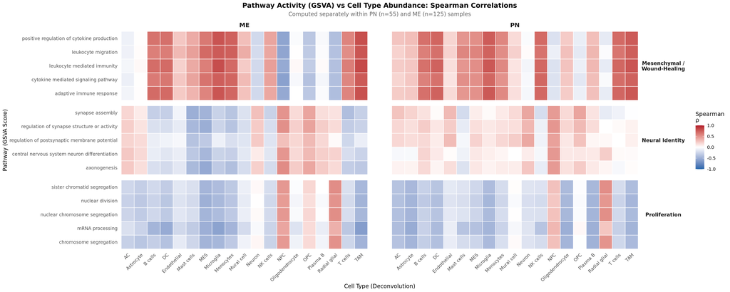

```r
# clean up pathway labels for display: strip theme prefix and replace dots with spaces
heatmap_data <- correlation_by_subtype %>%
  mutate(
    Theme = case_when(
      str_starts(Pathway, "MesWoundHealing__") ~ "Mesenchymal /\nWound-Healing",
      str_starts(Pathway, "Proliferation__")   ~ "Proliferation",
      str_starts(Pathway, "Neural__")          ~ "Neural Identity"
    ),
    Pathway_Label = Pathway %>%
      str_remove("^(MesWoundHealing|Proliferation|Neural)__") %>%
      str_replace_all("\\.", " ")
  )



# plot side-by-side heatmaps, one per subtype
pathway_celltype_correlation_heatmap <- ggplot(
  heatmap_data,
    aes(
      x    = CellType,
      y    = Pathway_Label,
      fill = rho
    )
  ) +

  geom_tile(
    color     = "white",
    linewidth = 0.4
  ) +

  scale_fill_gradient2(
    low      = "#2166AC",
    mid      = "white",
    high     = "#B2182B",
    midpoint = 0,
    limits   = c(-1, 1),
    name     = "Spearman\nρ"
  ) +

  facet_grid(
    rows   = vars(Theme),
    cols   = vars(Subtype),
    scales = "free_y",
    space  = "free_y"
  ) +

  labs(
    title    = "Pathway Activity (GSVA) vs Cell Type Abundance: Spearman Correlations",
    subtitle = "Computed separately within PN (n=55) and ME (n=125) samples",
    x        = "Cell Type (Deconvolution)",
    y        = "Pathway (GSVA Score)"
  ) +

  theme_minimal() +
  theme(
    axis.text.x     = element_text(angle = 45, hjust = 1, size = 9),
    axis.text.y     = element_text(size = 9),

    strip.text.y    = element_text(angle = 0, face = "bold", size = 10),
    strip.text.x    = element_text(face = "bold", size = 12),

    panel.grid      = element_blank(),
    panel.spacing.x = unit(1.5, "cm"),

    plot.title      = element_text(face = "bold", hjust = 0.5),
    plot.subtitle   = element_text(hjust = 0.5, color = "grey40"),

    legend.position = "right"
  )

pathway_celltype_correlation_heatmap
```

The heatmap reveals that the **relationship between cell type abundance and pathway activity is consistent across both subtypes**. The **correlation patterns** are **strikingly similar in ME and PN samples**, indicating that these biological associations are a **general property of GBM tumors** rather than subtype-specific phenomena.

The **correlations being similar** within each subtype **simply confirms these relationships are real** **and consistent**, **not artifacts** of group-level subtype differences.

### 3.4. Plot Kaplan-Meier Patient Survival Curves

#### 3.4.1. Prepare Patient Survival Data

```r
# extract survival-relevant columns from tumor_subtype_info
# using paper-curated columns (Verhaak/TCGA paper) which are more complete
# than the raw GDC clinical metadata for this specific dataset

patient_survival_data <- tumor_subtype_info %>%
  as.data.frame() %>%
  dplyr::select(
    sample_id             = barcode,
    bcr_patient_barcode,
    subtype               = paper_Transcriptome.Subtype,
    survival_months       = paper_Survival..months.,
    vital_status          = paper_Vital.status..1.dead.,
    age_at_diagnosis      = paper_Age..years.at.diagnosis.,
    karnofsky_score       = paper_Karnofsky.Performance.Score
  ) %>%

  mutate(
    # event = 1 (dead), event = 0 (censored/alive)
    # paper_Vital.status..1.dead. is already coded as 1/0
    event   = as.numeric(vital_status),
    subtype = factor(subtype, levels = c("PN", "ME"))
  ) %>%

  filter(!is.na(survival_months), !is.na(event))



cat("Samples with complete patient survival data:", nrow(patient_survival_data), "\n")
```

```
Samples with complete patient survival data: 180
```

```r
cat("\nEvent distribution (0 = censored, 1 = dead):\n")
```

```
Event distribution (0 = censored, 1 = dead):
```

```r
print(table(patient_survival_data$event, useNA = "always"))
```

```
   0    1 <NA>
  53  127    0
```

```r
cat("\nSubtype distribution:\n")
```

```
Subtype distribution:
```

```r
print(table(patient_survival_data$subtype, useNA = "always"))
```

```
  PN   ME <NA>
  55  125    0
```

```r
cat("\nMissingness check:\n")
```

```
Missingness check:
```

```r
cat("Missing survival_months:  ", sum(is.na(patient_survival_data$survival_months)), "\n")
```

```
Missing survival_months:   0
```

```r
cat("Missing event:            ", sum(is.na(patient_survival_data$event)), "\n")
```

```
Missing event:             0
```

```r
cat("Missing age_at_diagnosis: ", sum(is.na(patient_survival_data$age_at_diagnosis)), "\n")
```

```
Missing age_at_diagnosis:  0
```

#### 3.4.2. Plot Kaplan-Meier Patient Survival Curves

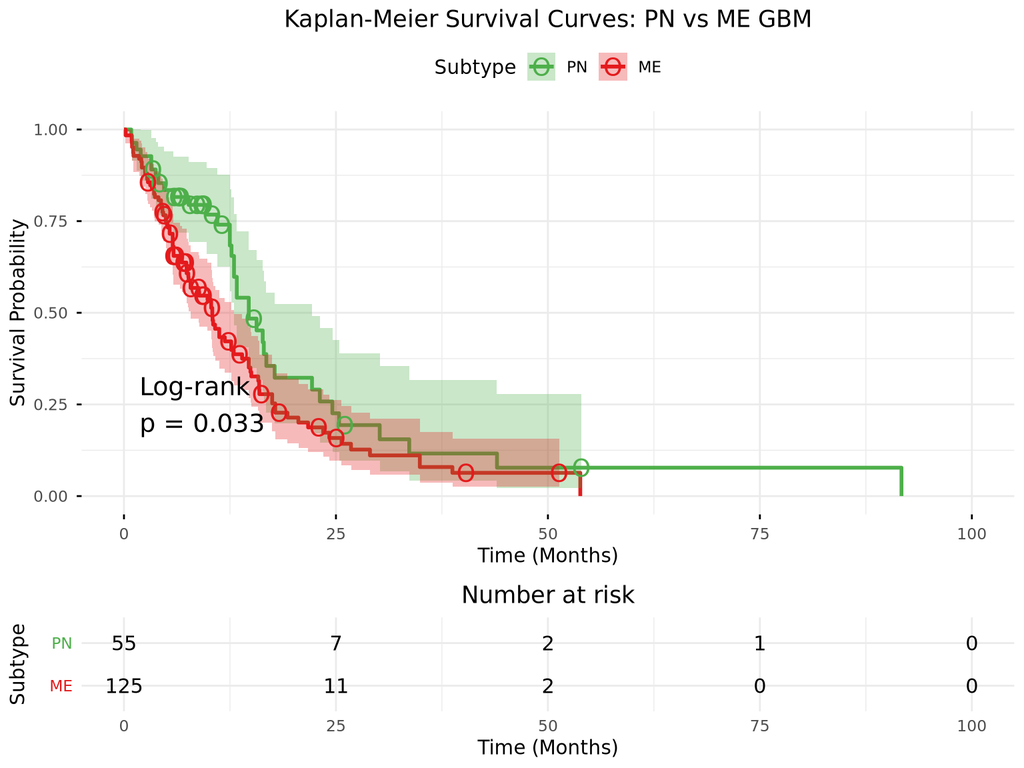

```r
# build survival object
surv_object <- Surv(
  time  = patient_survival_data$survival_months,
  event = patient_survival_data$event
)

# fit KM curves separately for ME and PN
km_fit <- survfit(surv_object ~ subtype, data = patient_survival_data)

# plot
km_plot <- ggsurvplot(
  km_fit,
  data          = patient_survival_data,

  pval          = TRUE,  # show log-rank test p-value
  pval.method   = TRUE,  # show the test name alongside p-value
  conf.int      = TRUE,  # show 95% confidence intervals
  risk.table    = TRUE,  # show number at risk below plot

  legend.labs   = c("PN", "ME"),
  legend.title  = "Subtype",

  palette       = c("#4DAF4A", "#E41A1C"),  # green for PN, red for ME
  censor.shape = "O",                       # marker for censored patients (i.e. those still alive at last follow-up, not counted in calculations from that point onwards)

  xlab          = "Time (Months)",
  ylab          = "Survival Probability",

  title         = "Kaplan-Meier Survival Curves: PN vs ME GBM",
  ggtheme       = theme_minimal() + theme(plot.title = element_text(hjust = 0.5)),
  fontsize      = 4
)

km_plot
```

The Kaplan-Meier survival curves show a **statistically significant survival difference** between PN and ME GBM subtypes **(log-rank p = 0.033)**:

- **Proneural (PN) patients survive longer on average**, with the **curve dropping more slowly** and **extending further right**. **Some** PN patients surviving **beyond 75 months**.
- **Mesenchymal (ME) patients** show **faster early decline**, with the **curve dropping more steeply in the first 25 months** where most GBM deaths occur.

The **shaded bands around each curve are 95% confidence intervals**, which means the **true survival probability at any given timepoint lies within this band with 95% certainty**. The **wider the band, the more uncertain the estimate**, which is why the **bands widen dramatically toward the right as fewer patients remain**.

The **“O” marks on the curves** represent **censored patients**, i.e. patients who were **still alive at their last recorded follow-up** and therefore **removed from the calculations from that point onwards**, since we **do not know their true survival time**, only that they survived at least that long.

**This rapid drop** in numbers at risk **is why the confidence intervals widen** so dramatically **toward the right**. With **very few patients remaining**, **each individual death causes a large step down** in the curve, **making the** **estimates increasingly uncertain**. Survival **estimates beyond month 25** should therefore be **interpreted with caution.**

**NOTE**: The **numbers at risk do NOT mean only those patients that are still alive at a particular timepoint; it also reflects censored patients**.

- For e.g. **in month 25**, it means **only 7 PN patients are still actively contributing survival information at that point**.
- **The rest either died** (accounted for as **steps in the curve**) or **were censored before month 25** (**removed from further calculations** without a death event).

The **log-rank `p = 0.033` confirms this difference is statistically real** and not due to chance, validating that **subtype is a meaningful predictor of survival**. This will **now be tested by the Cox model** in the **context of all biological variables simultaneously**, i.e:

- **Subtype (ME vs PN)**: The primary biological grouping variable
- **Pathways: One representative GSVA score per biological theme**:
  - One **immune pathway** score
  - One **neural pathway** score
  - One **proliferation pathway** score

    selected as the **highest-confidence representative of each theme**
- **Key cell type abundance scores**: Specifically **those identified by the correlation analysis** as **independently driving pathway activity** rather than being redundant with each other or with the GSVA scores
- **Age of patient at diagnosis**: The **single most established clinical confounder in GBM survival**, included to **ensure subtype effects are not confounded by patient age.**

The **outcome variable is overall survival**, defined as **time from diagnosis to death** **(or last follow-up if censored)**

## 4. Fit Cox Proportional Hazards Model

### 4.1. Select Cox Model Inputs

```r
# pathway-pathway score correlations
# compute pairwise Spearman correlations between all GSVA pathway scores
# using the full 180-sample dataset (not the subtype-split dataset, since overall redundancy is required)
gsva_score_cols <- pathway_cols

gsva_cor_matrix <- gsva_pathway_integration_df %>%

  dplyr::select(
    all_of(gsva_score_cols)
  ) %>%

  cor(method = "spearman") %>%
  abs()



# cell type-cell type score correlations
# compute pairwise Spearman correlations between all cell type abundance scores
celltype_cor_matrix <- gsva_pathway_integration_df %>%

  dplyr::select(
    all_of(cell_type_cols)
  ) %>%

  cor(method = "spearman") %>%
  abs()


# helper function
# greedy forward selection: start with highest mean_abs_rho variable,
# add next variable only if abs(rho) < 0.7 with ALL already-selected variables
greedy_select <- function(
    importance_df, cor_matrix, max_cor_threshold, min_importance
  ) {
      # filter to variables meeting minimum informativeness threshold
      candidates <- importance_df %>%
        filter(
          mean_abs_rho >= min_importance
        ) %>%
        pull(variable)

      selected <- c()

      for (candidate in candidates) {
        if (length(selected) == 0) {

          # always select the most important variable first
          selected <- c(selected, candidate)

        } else {

          # add candidate only if sufficiently independent from all already-selected variables
          max_cor <- max(
            cor_matrix[candidate, selected]
          )

          if (max_cor < max_cor_threshold) {
            selected <- c(selected, candidate)
          }
        }
      }
      return(selected)
  }



# pathway importance: mean absolute rho across all cell types and both subtypes
pathway_importance <- correlation_by_subtype %>%
  group_by(Pathway) %>%

  summarise(
    mean_abs_rho = mean(abs(rho))
  ) %>%

  arrange(
    desc(mean_abs_rho)
  ) %>%

  dplyr::rename(variable = Pathway)


# cell type importance: mean absolute rho across all pathways and both subtypes
celltype_importance <- correlation_by_subtype %>%
  group_by(CellType) %>%

  summarise(
    mean_abs_rho = mean(abs(rho))
  ) %>%

  arrange(
    desc(mean_abs_rho)
  ) %>%

  dplyr::rename(variable = CellType)



# apply greedy selection
selected_pathways  <- greedy_select(pathway_importance,  gsva_cor_matrix,
                                    max_cor_threshold = 0.8, min_importance = 0.15)
selected_celltypes <- greedy_select(celltype_importance, celltype_cor_matrix,
                                    max_cor_threshold = 0.7, min_importance = 0.3)

cat("Selected GSVA pathways (non-redundant, greedy forward selection):\n")
```

```
Selected GSVA pathways (non-redundant, greedy forward selection):
```

```r
print(selected_pathways)
```

```
[1] "MesWoundHealing__positive.regulation.of.cytokine.production"
[2] "Proliferation__nuclear.division"
[3] "Neural__synapse.assembly"
```

```r
cat("\nSelected cell types (non-redundant, greedy forward selection):\n")
```

```
Selected cell types (non-redundant, greedy forward selection):
```

```r
print(selected_celltypes)
```

```
[1] "TAM" "NPC"
```

```r
cat("\nFinal Cox model inputs:\n")
```

```
Final Cox model inputs:
```

```r
cat("- Subtype (ME vs PN)\n")
```

```
- Subtype (ME vs PN)
```

```r
cat("- Age at diagnosis\n")
```

```
- Age at diagnosis
```

```r
for (p in selected_pathways) {
  cat(
    paste0("- GSVA: ", p, "\n")
  )
}
```

```
- GSVA: MesWoundHealing__positive.regulation.of.cytokine.production
- GSVA: Proliferation__nuclear.division
- GSVA: Neural__synapse.assembly
```

```r
for (c in selected_celltypes) {
  cat(
    paste0("- Cell type: ", c, "\n")
  )
}
```

```
- Cell type: TAM
- Cell type: NPC
```

```r
cat(
  "\nTotal predictors:", 2 + length(selected_pathways) + length(selected_celltypes), "\n"
)
```

```
Total predictors: 7
```

### 4.2. Fit Cox Proportional Hazards Model

```r
# join selected Cox model inputs with survival data
cox_input_df <- patient_survival_data %>%
  left_join(
    gsva_pathway_integration_df %>%

    dplyr::select(
      sample_id,
      all_of(selected_pathways),
      all_of(selected_celltypes)
    ),

    by = "sample_id"
  ) %>%

  mutate(
    # standardize cell type abundance scores to mean=0, sd=1
    # MCPcounter abundance scores are on an arbitrary scale where one unit
    # is not meaningful. Standardizing makes their hazard ratios interpretable
    # as the effect of one standard deviation increase in cell type abundance
    TAM = scale(TAM)[, 1],
    NPC = scale(NPC)[, 1]
  )



cat("Cox model input dimensions:", dim(cox_input_df), "\n")
```

```
Cox model input dimensions: 180 13
```

```r
cat("Missing values per predictor:\n")
```

```
Missing values per predictor:
```

```r
cox_input_df %>%
dplyr::select(
  subtype, age_at_diagnosis,
  all_of(selected_pathways),
  all_of(selected_celltypes)
) %>%

summarise(
  across(
    everything(), ~ sum(is.na(.))
  )
) %>%
knitr::kable()
```

| subtype | age_at_diagnosis | MesWoundHealing__positive.regulation.of.cytokine.production | Proliferation__nuclear.division | Neural__synapse.assembly | TAM | NPC |
| --- | --- | --- | --- | --- | --- | --- |
| 0 | 0 | 0 | 0 | 0 | 0 | 0 |

```r
# build formula dynamically from selected variables
cox_formula <- as.formula(
  paste(
    "Surv(survival_months, event) ~",
    paste(
      c(
        "subtype",
        "age_at_diagnosis",
        paste0("`", selected_pathways, "`"),
        paste0("`", selected_celltypes, "`")
      ),
      collapse = " + "
    )
  )
)

cat("\nCox model formula:\n")
```

```
Cox model formula:
```

```r
print(cox_formula)
```

```
Surv(survival_months, event) ~ subtype + age_at_diagnosis + MesWoundHealing__positive.regulation.of.cytokine.production +
    Proliferation__nuclear.division + Neural__synapse.assembly +
    TAM + NPC
```

```r
# fit Cox proportional hazards model
cox_model <- coxph(cox_formula, data = cox_input_df)

# display results
cat("\nCox model summary:\n")
```

```
Cox model summary:
```

```r
summary(cox_model)
```

```
Call:
coxph(formula = cox_formula, data = cox_input_df)

  n= 180, number of events= 127

                                                                 coef exp(coef)
subtypeME                                                   -0.019626  0.980565
age_at_diagnosis                                             0.045406  1.046453
MesWoundHealing__positive.regulation.of.cytokine.production  1.326645  3.768379
Proliferation__nuclear.division                              0.608939  1.838480
Neural__synapse.assembly                                     0.371041  1.449242
TAM                                                         -0.151654  0.859286
NPC                                                          0.049175  1.050405
                                                             se(coef)      z
subtypeME                                                    0.370760 -0.053
age_at_diagnosis                                             0.008445  5.377
MesWoundHealing__positive.regulation.of.cytokine.production  0.663932  1.998
Proliferation__nuclear.division                              0.385378  1.580
Neural__synapse.assembly                                     0.393226  0.944
TAM                                                          0.191505 -0.792
NPC                                                          0.162980  0.302
                                                            Pr(>|z|)
subtypeME                                                     0.9578
age_at_diagnosis                                            7.59e-08 ***
MesWoundHealing__positive.regulation.of.cytokine.production   0.0457 *
Proliferation__nuclear.division                               0.1141
Neural__synapse.assembly                                      0.3454
TAM                                                           0.4284
NPC                                                           0.7629
---
Signif. codes:  0 '***' 0.001 '**' 0.01 '*' 0.05 '.' 0.1 ' ' 1

                                                            exp(coef)
subtypeME                                                      0.9806
age_at_diagnosis                                               1.0465
MesWoundHealing__positive.regulation.of.cytokine.production    3.7684
Proliferation__nuclear.division                                1.8385
Neural__synapse.assembly                                       1.4492
TAM                                                            0.8593
NPC                                                            1.0504
                                                            exp(-coef)
subtypeME                                                       1.0198
age_at_diagnosis                                                0.9556
MesWoundHealing__positive.regulation.of.cytokine.production     0.2654
Proliferation__nuclear.division                                 0.5439
Neural__synapse.assembly                                        0.6900
TAM                                                             1.1638
NPC                                                             0.9520
                                                            lower .95 upper .95
subtypeME                                                      0.4741     2.028
age_at_diagnosis                                               1.0293     1.064
MesWoundHealing__positive.regulation.of.cytokine.production    1.0257    13.845
Proliferation__nuclear.division                                0.8638     3.913
Neural__synapse.assembly                                       0.6705     3.132
TAM                                                            0.5904     1.251
NPC                                                            0.7632     1.446

Concordance= 0.67  (se = 0.029 )
Likelihood ratio test= 37  on 7 df,   p=5e-06
Wald test            = 33.45  on 7 df,   p=2e-05
Score (logrank) test = 34.5  on 7 df,   p=1e-05
```

### 4.3. Visualize Cox Model Results In Forest Plot

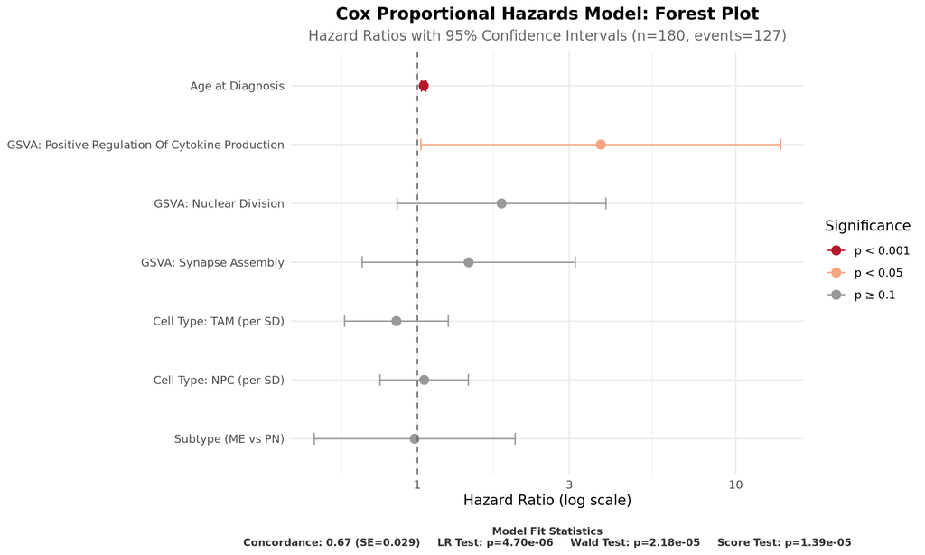

```r
# build readable name mapping dynamically based on actual selected variables
readable_term_names <- c(
  "subtypeME"        = "Subtype (ME vs PN)",
  "age_at_diagnosis" = "Age at Diagnosis",
  setNames(
    paste0(
      "GSVA: ",
      str_remove(
        selected_pathways, "^(MesWoundHealing|Proliferation|Neural)__"
      ) %>%
      str_replace_all("\\.", " ") %>%
      str_to_title()
    ),
    selected_pathways
  ),
  setNames(
    paste0("Cell Type: ", selected_celltypes, " (per SD)"),
    selected_celltypes
  )
)

# extract clean hazard ratio table for forest plot
cox_results <- broom::tidy(
    cox_model,            # cox model
    exponentiate = TRUE,  # hazard ratios (explained below) are in log form, so exponentiate them to normal scale for interpretation
    conf.int     = TRUE   # calculate confidence interval (default is 95% CI)
  ) %>%

  # rename variables to human readable forms
  mutate(term = readable_term_names[term]) %>%

  arrange(p.value) %>%

  mutate(
    term         = factor(term, levels = rev(term)),  # rev() so smallest p.value appears at top
    significance = case_when(
      p.value < 0.001 ~ "p < 0.001",
      p.value < 0.01  ~ "p < 0.01",
      p.value < 0.05  ~ "p < 0.05",
      p.value < 0.1   ~ "p < 0.1",
      TRUE            ~ "p ≥ 0.1"
    )
  )






# forest plot
cox_forest_plot <- ggplot(
    cox_results,
    aes(
      x = estimate,
      y = term,
      color = significance
    )
  ) +


  geom_point(size = 3) +

  geom_errorbarh(
    aes(
      xmin = conf.low,
      xmax = conf.high
    ),
    height = 0.2
  ) +

  geom_vline(
    xintercept = 1,
    linetype   = "dashed",
    color      = "grey40"
  ) +


  scale_color_manual(
    values = c(
      "p < 0.001" = "#B2182B",
      "p < 0.01"  = "#D6604D",
      "p < 0.05"  = "#F4A582",
      "p < 0.1"   = "#FDDBC7",
      "p ≥ 0.1"   = "grey60"
    ),
    name = "Significance"
  ) +

  scale_x_log10() +              # log scale so HR=1 is centered, symmetric display

  labs(
    title    = "Cox Proportional Hazards Model: Forest Plot",
    subtitle = "Hazard Ratios with 95% Confidence Intervals (n=180, events=127)",
    x        = "Hazard Ratio (log scale)",
    y        = NULL,

    caption = paste0(
      "Model Fit Statistics\n",


      # Concordance; asks:
        # "If two patients are randomly picked from the dataset
        # and the model is used to predict which one would die sooner,
        # how often would the model be correct?"
      "Concordance: ",
      round(
        summary(cox_model)$concordance[1], 3
      ),

      # standard error of concordance
      " (SE=",
      round(
        summary(cox_model)$concordance[2], 3
      ),
      ")     ",




      # Likelihood Ratio Test; asks:
        # "If the model is given NO information about these patients at all,
        # i.e. no age, no subtype, no pathways, nothing,
        # and predicted survival purely by chance,
        # how much worse would it do compared to using all 7 predictors?"
      "LR Test: p=",
      formatC(
        summary(cox_model)$logtest[3],  format = "e", digits = 2
      ),
      "     ",




      # Wald test; asks:
        # "Looking at each predictor's estimated effect
        # and how uncertain the model is about that estimate,
        # is the model confident enough that
        # at least some of these effects are real and not just noise?"
      "Wald Test: p=",
      formatC(
        summary(cox_model)$waldtest[3], format = "e", digits = 2
      ),
      "     ",




      # Score test; asks:
        # "Without even fully fitting the model,
        # just standing at the starting point where all predictors have zero effect,
        # does the data immediately push back and say 'no, these predictors clearly matter'?"
      "Score Test: p=",
      formatC(
        summary(cox_model)$sctest[3],  format = "e", digits = 2
      )
    )
  ) +
  theme_minimal() +
  theme(
    plot.title    = element_text(face = "bold", hjust = 0.5),
    plot.subtitle = element_text(hjust = 0.5, color = "grey40"),
    plot.caption = element_text(
      hjust = 0.5,
      margin = margin(t = 15),
      face = "bold",
      size = 8,
      color = "grey20"
    ),
    legend.position = "right"
  )

cox_forest_plot
```

The Cox proportional hazards model was fit with **7 predictors across 180 samples and 127 death events**. **Variable selection** followed a **hybrid approach**:

- **Literature-informed inclusion**: *Subtype (ME vs PN)* **as the primary biological variable** and *age at diagnosis* as a **standard clinical covariate** included to control for its **known confounding effect on survival in GBM.**
- **Data-driven importance ranking**: Remaining *candidate pathways (3)* and *cell types (2)* were **ranked by their mean absolute correlation with the opposing variable type** **(pathway-celltype correlation from Section 3.3)**, selecting the most **biologically grounded representative of each theme.**
- **Greedy redundancy removal**: Variables were added **sequentially**, including a candidate **only if its absolute pairwise correlation with all already-selected variables of the same type was BELOW the specified threshold**, ensuring no two predictors measure the same underlying signal.

**Cell type abundance scores (of TAM, NPC) were standardized to mean=0, SD=1 prior to model fitting**, since **`MCPcounter` abundance scores** are on an **arbitrary numeric scale** where a **“one unit increase” is not meaningful**. **Standardization** makes their **hazard ratios interpretable as the effect of one standard deviation increase in cell type abundance.**

The **forest plot above** shows the **hazard ratio (HR) and 95% confidence interval for each predictor**, on a **log scale**. A **point to the right of the dashed line (HR=1)** indicates **higher risk**; a **point to the left** indicates **lower risk**. **Color** reflects **statistical significance**.

**NOTE: Hazard Ratio (HR)** **=** **relative change in hazard rate per unit increase in variable**

**Overall model significance**: all **three tests agree strongly** that the **model as a whole significantly predicts survival better than no predictors** at all:

- **Likelihood Ratio Test** `p = 5e-06`
- **Wald Test** `p = 2e-05`
- **Score Test** `p = 1e-05`

The **concordance of 0.67** indicates the **model correctly ranks which of two randomly chosen patients will die sooner 67% of the time**. This is **meaningfully better than random chance (i.e. 0.5)**, though **not perfect**, reflecting the **inherent biological variability in individual GBM survival**.

**Individual predictor results** (see forest plot):

- **Age at Diagnosis (HR=1.046, p=`7.59e-08`)**: The single **strongest, most significant predictor**. **Each additional year of age at diagnosis increases the hazard of death by 4.6%**, controlling for all other variables. This is **entirely consistent with age being the most established prognostic factor in GBM**, i.e. **older patients consistently fare worse regardless of subtype.**
- **GSVA: Positive Regulation Of Cytokine Production** **(HR=3.768, `p=0.0457`)** is **the only pathway score** reaching **conventional statistical significance**. Its **95% CI (1.026 - 13.845) excludes 1**, indicating **tumors with elevated cytokine production signaling** face **significantly worse survival**, independent of subtype, age, and cell composition. This provides direct quantitative support for the **mesenchymal/wound-healing program** being **clinically detrimental**, not just transcriptionally distinct.
- **All other predictors** (GSVA: Nuclear Division, GSVA: Synapse Assembly, Cell Type: TAM, Cell Type: NPC) show **no statistically significant independent survival association**.
- **Subtype ME vs PN (HR=0.981, p=`0.958`)**: The **most striking finding**: **subtype alone shows no significant independent effect on survival** when biological variables are controlled for. The **KM plot (Section 3.4) showed a significant ME vs PN survival difference (`p=0.033`)**, but **that difference disappears in the multivariate model**. This **suggests subtype’s effect on survival is mediated through the biological variables** in the model, particularly **age and immune pathway activity**, rather than being a direct, independent effect of the subtype label itself. In other words, **it is not “being ME” that kills patients faster**, but **rather the biological characteristics that ME tumors tend to have** (older patients, higher immune/inflammatory activity) that **drive the** **worse prognosis**.

### 4.4. Check Proportional Hazards Assumption With Schoenfeld Residuals Plot

```r
# build readable name mapping dynamically based on actual selected variables
readable_names <- c(
  "subtype"          = "Subtype (ME vs PN)",
  "age_at_diagnosis" = "Age at Diagnosis",
  setNames(
    paste0(
      "GSVA: ",
      str_remove(
        selected_pathways,
        "^(MesWoundHealing|Proliferation|Neural)__"
      ) %>%
      str_replace_all("\\.", " ") %>%
      str_to_title()
    ),
    selected_pathways
  ),
  setNames(
    paste0("Cell Type: ", selected_celltypes, " (per SD)"),
    selected_celltypes
  )
)

# test proportional hazards assumption using Schoenfeld residuals
# null hypothesis: hazard ratio for each predictor is constant over time
schoenfeld_residuals_ph_test <- cox.zph(cox_model)



# rename terms in schoenfeld_residuals_ph_test object for readable plot labels
# test result table row names (summary stats of residuals results, one per predictor + GLOBAL)
rownames(schoenfeld_residuals_ph_test$table) <- c(
  readable_names[
    rownames(
      schoenfeld_residuals_ph_test$table
    )[
      -nrow(schoenfeld_residuals_ph_test$table)
    ]
  ],
  "GLOBAL"
)


# scaled Schoenfeld residuals matrix column names (residuals themselves)
colnames(schoenfeld_residuals_ph_test$y)   <- readable_names[
  colnames(
    schoenfeld_residuals_ph_test$y
  )
]


# variance matrix (used internally by cox_zph()) column names
colnames(schoenfeld_residuals_ph_test$var) <- readable_names[
  colnames(
    schoenfeld_residuals_ph_test$var
  )
]


# variance matrix (used internally by cox_zph()) row names
rownames(schoenfeld_residuals_ph_test$var) <- readable_names[
  rownames(
    schoenfeld_residuals_ph_test$var
  )
]


cat("Schoenfeld Residuals Test (Proportional Hazards Assumption):\n\n")
```

```
Schoenfeld Residuals Test (Proportional Hazards Assumption):
```

```r
print(schoenfeld_residuals_ph_test)
```

```
                                                 chisq df     p
Subtype (ME vs PN)                                2.07  1 0.151
Age at Diagnosis                                  2.24  1 0.134
GSVA: Positive Regulation Of Cytokine Production  1.61  1 0.205
GSVA: Nuclear Division                            2.60  1 0.107
GSVA: Synapse Assembly                            3.86  1 0.049
Cell Type: TAM (per SD)                           1.98  1 0.159
Cell Type: NPC (per SD)                           2.65  1 0.103
GLOBAL                                            7.03  7 0.426
```

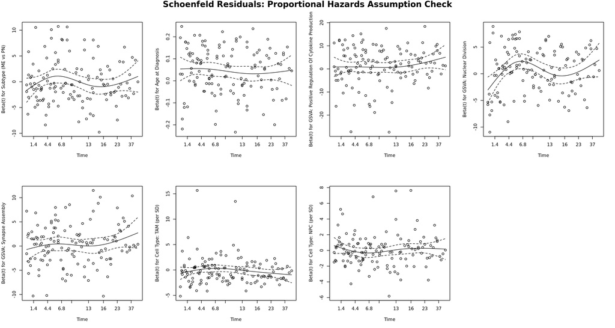

```r
# plot Schoenfeld residuals for each predictor
# a flat, random scatter around zero indicates the assumption holds
# a systematic trend over time indicates a violation
par(mfrow = c(2, 4))
plot(schoenfeld_residuals_ph_test)
mtext(
  "Schoenfeld Residuals: Proportional Hazards Assumption Check",
  side  = 3,
  line  = -1.5,
  outer = TRUE,
  font  = 2,
  cex   = 1.2
)
```

The **Schoenfeld residuals test evaluates whether the core assumption of the Cox model holds**, the **assumption being that each predictor’s effect on survival risk remains constant over time rather than strengthening or weakening as patients are followed longer**.

For **each predictor**, **the test asks: “do the residuals show any systematic trend over time?”** A **non-significant p-value (p > 0.05) means no detectable trend**, meaning that **the assumption holds for that predictor**.

**Results**: **all predictors pass** the assumption check at the conventional threshold, with **one borderline exception**:

| Predictor | p-value | Interpretation |
| --- | --- | --- |
| Subtype | 0.151 | Assumption holds |
| Age at Diagnosis | 0.134 | Assumption holds |
| GSVA: Positive Regulation of Cytokine Production | 0.205 | Assumption holds |
| GSVA: Nuclear Division | 0.107 | Assumption holds |
| GSVA: Synapse Assembly | 0.049 | Borderline violation |
| Cell Type: TAM | 0.159 | Assumption holds |
| Cell Type: NPC | 0.103 | Assumption holds |
| **GLOBAL** | **0.426** | **Assumption holds globally** |

The **global test (`p = 0.426`)** **confirms** that the **model as a whole does not violate the proportional hazards assumption.** One individual predictor (GSVA: Synapse Assembly) shows a **borderline** result (`p = 0.049`) at the individual level, but this **does not affect the global assumption test**, and this **predictor was not statistically significant** in the Cox model itself (HR=1.449, `p=0.345`). **No corrections are required**; the **Cox model results in Section 4.3 are statistically valid and can be interpreted as stated.**

## 5. Save Outputs

### 5.1. Save Results

```r
# integrated pathway analysis summary table
write_csv(
  pathway_analysis_results_integrated_summary,
  "../04_results/08_integration_and_interpretation/01_pathway_analysis_integrated_summary.csv"
)

# gsva per-sample pathway activity scores
saveRDS(
  gsva_scores,
  "../04_results/08_integration_and_interpretation/02_gsva_pathway_activity_scores.rds"
)

# pathway-celltype correlation results
write_csv(
  correlation_by_subtype,
  "../04_results/08_integration_and_interpretation/03_pathway_celltype_correlation_results.csv"
)



# patient survival data
write_csv(
  patient_survival_data,
  "../04_results/08_integration_and_interpretation/04_patient_survival_data.csv"
)



# fitted cox model object
saveRDS(
  cox_model,
  "../04_results/08_integration_and_interpretation/05_cox_model.rds"
)

# cox model results (hazard ratios, CIs, p-values)
write_csv(
  cox_results,
  "../04_results/08_integration_and_interpretation/06_cox_model_results.csv"
)



# schoenfeld residuals test object
saveRDS(
  schoenfeld_residuals_ph_test,
  "../04_results/08_integration_and_interpretation/07_schoenfeld_residuals_test.rds"
)

cat("Saved 4 CSV files and 3 RDS files.")
```

```
Saved 4 CSV files and 3 RDS files.
```

### 5.2. Save Plots

```r
# pathway-celltype correlation heatmap
ggsave(
  "../03_figures/08_integration_and_interpretation/01_pathway_celltype_correlation_heatmap.png",
  plot   = pathway_celltype_correlation_heatmap,
  width  = 20,
  height = 8,
  dpi    = 300
)

# kaplan-meier survival curves plot
png(
  "../03_figures/08_integration_and_interpretation/02_km_survival_curves.png",
  width  = 8,
  height = 8,
  units  = "in",
  res    = 300
)
print(km_plot)
dev.off()
```

```r
# cox model forest plot
ggsave(
  "../03_figures/08_integration_and_interpretation/03_cox_forest_plot.png",
  plot   = cox_forest_plot,
  width  = 10,
  height = 6,
  dpi    = 300
)

# schoenfeld residuals plot
png(
  "../03_figures/08_integration_and_interpretation/04_schoenfeld_residuals.png",
  width  = 15,
  height = 8,
  units  = "in",
  res    = 300
)
par(mfrow = c(2, 4))
plot(schoenfeld_residuals_ph_test)
mtext(
  "Schoenfeld Residuals: Proportional Hazards Assumption Check",
  side  = 3,
  line  = -1.5,
  outer = TRUE,
  font  = 2,
  cex   = 1.2
)
dev.off()
```

```r
cat("Saved 4 plots.")
```

```
Saved 4 plots.
```

## 6. Perform Sanity Checks

```r
# data files
pathway_analysis_integrated_summary_exists  <- file.exists("../04_results/08_integration_and_interpretation/01_pathway_analysis_integrated_summary.csv")
gsva_pathway_activity_scores_exists         <- file.exists("../04_results/08_integration_and_interpretation/02_gsva_pathway_activity_scores.rds")
pathway_celltype_correlation_results_exists <- file.exists("../04_results/08_integration_and_interpretation/03_pathway_celltype_correlation_results.csv")
patient_survival_data_exists                <- file.exists("../04_results/08_integration_and_interpretation/04_patient_survival_data.csv")
cox_model_exists                            <- file.exists("../04_results/08_integration_and_interpretation/05_cox_model.rds")
cox_model_results_exists                    <- file.exists("../04_results/08_integration_and_interpretation/06_cox_model_results.csv")
schoenfeld_residuals_test_exists            <- file.exists("../04_results/08_integration_and_interpretation/07_schoenfeld_residuals_test.rds")


# plot files
pathway_celltype_correlation_heatmap_exists <- file.exists("../03_figures/08_integration_and_interpretation/01_pathway_celltype_correlation_heatmap.png")
km_survival_curves_exists                   <- file.exists("../03_figures/08_integration_and_interpretation/02_km_survival_curves.png")
cox_forest_plot_exists                      <- file.exists("../03_figures/08_integration_and_interpretation/03_cox_forest_plot.png")
schoenfeld_residuals_exists                 <- file.exists("../03_figures/08_integration_and_interpretation/04_schoenfeld_residuals.png")



cat("Pathway analysis integrated summary saved:      ", ifelse(pathway_analysis_integrated_summary_exists,  "✓", "✗"), "\n")
```

```
Pathway analysis integrated summary saved:       ✓
```

```r
cat("GSVA pathway activity scores saved:             ", ifelse(gsva_pathway_activity_scores_exists,         "✓", "✗"), "\n")
```

```
GSVA pathway activity scores saved:              ✓
```

```r
cat("Pathway-celltype correlation results saved:     ", ifelse(pathway_celltype_correlation_results_exists, "✓", "✗"), "\n")
```

```
Pathway-celltype correlation results saved:      ✓
```

```r
cat("Patient survival data saved:                    ", ifelse(patient_survival_data_exists,                "✓", "✗"), "\n")
```

```
Patient survival data saved:                     ✓
```

```r
cat("Cox model saved:                                ", ifelse(cox_model_exists,                            "✓", "✗"), "\n")
```

```
Cox model saved:                                 ✓
```

```r
cat("Cox model results saved:                        ", ifelse(cox_model_results_exists,                    "✓", "✗"), "\n")
```

```
Cox model results saved:                         ✓
```

```r
cat("Schoenfeld residuals test saved:                ", ifelse(schoenfeld_residuals_test_exists,            "✓", "✗"), "\n\n")
```

```
Schoenfeld residuals test saved:                 ✓
```

```r
cat("Pathway-celltype correlation heatmap saved:     ", ifelse(pathway_celltype_correlation_heatmap_exists, "✓", "✗"), "\n")
```

```
Pathway-celltype correlation heatmap saved:      ✓
```

```r
cat("KM survival curves saved:                       ", ifelse(km_survival_curves_exists,                   "✓", "✗"), "\n")
```

```
KM survival curves saved:                        ✓
```

```r
cat("Cox forest plot saved:                          ", ifelse(cox_forest_plot_exists,                      "✓", "✗"), "\n")
```

```
Cox forest plot saved:                           ✓
```

```r
cat("Schoenfeld residuals plot saved:                ", ifelse(schoenfeld_residuals_exists,                 "✓", "✗"), "\n")
```

```
Schoenfeld residuals plot saved:                 ✓
```

```r
if (
  all(
    pathway_analysis_integrated_summary_exists,
    gsva_pathway_activity_scores_exists,
    pathway_celltype_correlation_results_exists,
    patient_survival_data_exists,
    cox_model_exists,
    cox_model_results_exists,
    schoenfeld_residuals_test_exists,

    pathway_celltype_correlation_heatmap_exists,
    km_survival_curves_exists,
    cox_forest_plot_exists,
    schoenfeld_residuals_exists
  )
) {
  cat("\nNotebook 08 complete — all outputs verified\n")
} else {
  cat("\nWARNING: One or more outputs missing\n")
}
```

```
Notebook 08 complete — all outputs verified
```